# Analyse statistique et stylométrie avec R

## Arbre de consensus

Parfois, on peut ne pas savoir exactement à quelle hauteur couper les effectifs. On peut vouloir en tester plusieurs, et chercher à dégager un consensus. C’est à ça que servent les arbres de consensus. Pour expérimenter avec eux, nous allons utiliser le module `stylo`.

[output not shown]

[figure not shown]

[output not shown]

```r
library(stylo)
#Pour lancer avec une interface graphique, et faire les choix par clic
#stylo(corpus.dir = "corpus_Corneille_moliere/txt/")
#Sinon
stylo(gui = FALSE, frequencies = t(theatre2), analysis.type="BCT", consensus.strength=0.5, corpus.lang="French", linkage="ward.D2", mfw.min=100, mfw.max=150, mfw.incr=50, culling.min=20, culling.max=100, distance.measure="dist.cosine")
```

La situation paraît plus complexe qu’attendue, avec des attractions multiples… Cela mérite en fait un peu plus d’analyse exploratoire.

## Analyse en composantes principales

### Première analyse

Pour réaliser notre première ACP (ou *PCA* en anglais), nous allons utiliser le module `FactoMineR`.

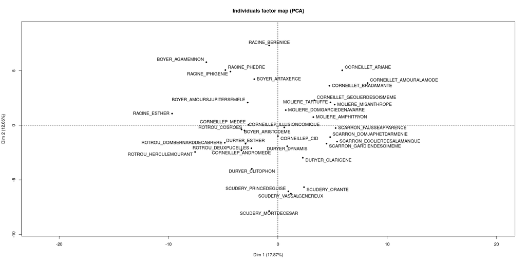

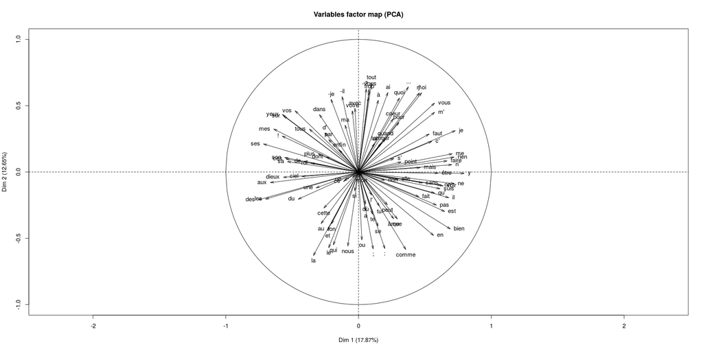

```r
#On charge FactoMineR
library('FactoMineR')
#Et on calcule l'ACP.  Comme la fonction attend les individus en ligne et les variables en colonnes, je transpose mon tableau avec t()
monACP = PCA(t(theatreTraite))
```

Je peux à présent examiner la significativité de chacun des axes produits, tout d’abord numériquement

```r
monACP$eig
```

```
##         eigenvalue percentage of variance
## comp 1  17.8685856             17.8685856
## comp 2  12.6485358             12.6485358
## comp 3   8.1623766              8.1623766
## comp 4   7.6105804              7.6105804
## comp 5   6.8488297              6.8488297
## comp 6   5.4166617              5.4166617
## comp 7   4.8571957              4.8571957
## comp 8   4.0566253              4.0566253
## comp 9   3.2254850              3.2254850
## comp 10  2.8916212              2.8916212
## comp 11  2.5962812              2.5962812
## comp 12  2.2960920              2.2960920
## comp 13  2.0749620              2.0749620
## comp 14  1.8525038              1.8525038
## comp 15  1.7554886              1.7554886
## comp 16  1.5989959              1.5989959
## comp 17  1.5613658              1.5613658
## comp 18  1.3915116              1.3915116
## comp 19  1.3277332              1.3277332
## comp 20  1.0754145              1.0754145
## comp 21  1.0386389              1.0386389
## comp 22  1.0279898              1.0279898
## comp 23  0.8715498              0.8715498
## comp 24  0.8001897              0.8001897
## comp 25  0.7636856              0.7636856
## comp 26  0.7089933              0.7089933
## comp 27  0.6466378              0.6466378
## comp 28  0.5766078              0.5766078
## comp 29  0.5262449              0.5262449
## comp 30  0.4337658              0.4337658
## comp 31  0.3930666              0.3930666
## comp 32  0.3887293              0.3887293
## comp 33  0.3071869              0.3071869
## comp 34  0.2231979              0.2231979
## comp 35  0.1766704              0.1766704
##         cumulative percentage of variance
## comp 1                           17.86859
## comp 2                           30.51712
## comp 3                           38.67950
```

[output cut: 17 more lines]

```
## comp 21                          92.15548
## comp 22                          93.18347
## comp 23                          94.05502
## comp 24                          94.85521
## comp 25                          95.61890
## comp 26                          96.32789
## comp 27                          96.97453
## comp 28                          97.55114
## comp 29                          98.07738
## comp 30                          98.51115
## comp 31                          98.90422
## comp 32                          99.29294
## comp 33                          99.60013
## comp 34                          99.82333
## comp 35                         100.00000
```

ou en la traçant comme un diagramme en bâtons,

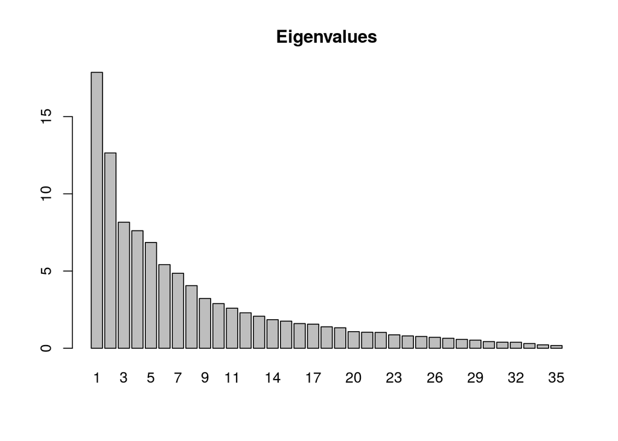

```r
barplot(monACP$eig[,1], main="Eigenvalues", names.arg=1:nrow(monACP$eig))
```

*Questions*: Que peut-on conclure de cet examen de la significativité des axes ? Quels axes méritent d’être examinés de près ?

Examinons à présent le premier plan factoriel (axes 1-2)

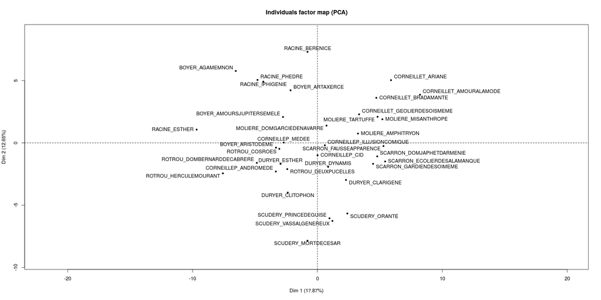

```r
plot.PCA(monACP)
```

*Question*: Ce résultat est-il pertinent ? Comment peut-on l’interpréter ?

L’axe 2 paraît renvoyer à une dimension chronologique, mais la pertinence du premier axe est encore peu claire.

## Positionnement multidimensionnel

### Métrique

Après cette première approche qui a consisté à réduire la dimensionnalité en «découpant» en une série de dimensions non corrélées entre elles, nous pouvons en tenter une autre qui consiste à «écraser» toutes les dimensions en deux seulement, pour résumer un maximum d’information.

Un outil pour faire cela est le Positionnement multidimensionnel (ou *Multidimensional scaling*, *MDS* en anglais).

Là aussi, le format attendu est un tableau dans lequel les lignes sont les individus et les colonnes les variables.

Commençons par calculer les distances entre nos individus (nous choisissons une nouvelle fois la distance de Manhattan de préférence à la distance euclidienne, mais nous pouvons aussi expérimenter avec MinMax); et nous «ajustons» sur deux dimensions,

```r
#Manhattan
#fit = cmdscale(dist(t(theatreTraite), method = "manhattan"),eig=TRUE, k=2) # k est le nombre de dimensions souhaité
#MinMax
fit = cmdscale(MinMax(theatreTraite),eig=TRUE, k=2) # k est le nombre de dimensions souhaité
```

Traçons à présent le graphique,

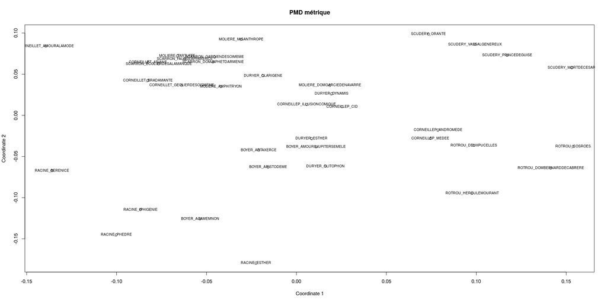

```r
x = fit$points[,1]
y = fit$points[,2]
plot(x, y, xlab="Coordinate 1", ylab="Coordinate 2", main="PMD métrique")
text(x, y, labels = row.names(t(theatreTraite)), cex=.7)
```

```r
fit
```

```
## $points
##                                      [,1]        [,2]
## BOYER_AGAMEMNON              -0.053598530 -0.12585450
## BOYER_AMOURSJUPITERSEMELE     0.010910836 -0.03827699
## BOYER_ARISTODEME             -0.015775828 -0.06291895
## BOYER_ARTAXERCE              -0.020941574 -0.04231196
## CORNEILLEP_ANDROMEDE          0.078694906 -0.01774712
## CORNEILLEP_CID                0.025327211  0.01053989
## CORNEILLEP_ILLUSIONCOMIQUE    0.005671569  0.01313925
## CORNEILLEP_MEDEE              0.074509552 -0.02801599
## CORNEILLET_AMOURALAMODE      -0.139243928  0.08409962
## CORNEILLET_ARIANE            -0.082601473  0.06461797
## CORNEILLET_BRADAMANTE        -0.082613492  0.04237267
## CORNEILLET_GEOLIERDESOISMEME -0.063830273  0.03658871
## DURYER_CLARIGENE             -0.018641177  0.04815612
## DURYER_CLITOPHON              0.016046872 -0.06180335
## DURYER_DYNAMIS                0.019558153  0.02629038
## DURYER_ESTHER                 0.008336840 -0.02810783
## MOLIERE_AMPHITRYON           -0.042003775  0.03497611
## MOLIERE_DOMGARCIEDENAVARRE    0.018632853  0.03645532
## MOLIERE_MISANTHROPE          -0.030748441  0.09230437
## MOLIERE_TARTUFFE             -0.066200264  0.07230825
## RACINE_BERENICE              -0.135950980 -0.06719149
## RACINE_ESTHER                -0.022444561 -0.17930439
## RACINE_IPHIGENIE             -0.086695346 -0.11450049
## RACINE_PHEDRE                -0.100179253 -0.14506741
## ROTROU_COSROES                0.153859823 -0.03763398
## ROTROU_DEUXPUCELLES           0.098621764 -0.03650172
## ROTROU_DOMBERNARDDECABRERE    0.141365560 -0.06416934
## ROTROU_HERCULEMOURANT         0.097631579 -0.09464912
## SCARRON_DOMJAPHETDARMENIE    -0.046385040  0.06476307
## SCARRON_ECOLIERDESALAMANQUE  -0.076502057  0.06256867
## SCARRON_FAUSSEAPPARENCE      -0.062046761  0.06835057
## SCARRON_GARDIENDESOIMEME     -0.045489748  0.07081013
## SCUDERY_MORTDECESAR           0.153076770  0.05776747
## SCUDERY_ORANTE                0.073349296  0.09880145
## SCUDERY_PRINCEDEGUISE         0.117090840  0.07283619
## SCUDERY_VASSALGENEREUX        0.099208076  0.08630842
##
## $eig
##  [1]  2.274471e-01  1.930329e-01  1.258411e-01  9.525828e-02  8.844891e-02
##  [6]  6.800014e-02  6.197984e-02  5.115251e-02  4.943588e-02  3.361941e-02
## [11]  3.000310e-02  2.756074e-02  2.538877e-02  2.285519e-02  2.080973e-02
## [16]  1.937687e-02  1.837661e-02  1.724251e-02  1.464839e-02  1.412430e-02
## [21]  1.205951e-02  1.145679e-02  9.592627e-03  8.176090e-03  7.508986e-03
## [26]  6.906847e-03  6.092613e-03  5.716421e-03  4.415123e-03  2.731816e-03
## [31]  2.352210e-03  9.025587e-04  2.190088e-17 -8.540503e-04 -1.000768e-03
## [36] -1.794824e-03
##
## $x
## NULL
##
## $ac
## [1] 0
##
## $GOF
## [1] 0.3269258 0.3278561
```

### Non métrique

La procédure ressemble à la précédente, excepté que nous utiliserons la fonction `isoMDS()` du module `MASS`,

```r
library(MASS)
#fit = isoMDS(dist(t(theatreTraite), method = "manhattan"), k=2)
fit = isoMDS(MinMax(theatreTraite), k=2)
fit
```

```
## $points
##                                      [,1]         [,2]
## BOYER_AGAMEMNON              -0.053718762 -0.092090229
## BOYER_AMOURSJUPITERSEMELE     0.009739621 -0.036840872
## BOYER_ARISTODEME             -0.014060491 -0.045623139
## BOYER_ARTAXERCE              -0.031764690 -0.031572179
## CORNEILLEP_ANDROMEDE          0.054462552 -0.009587633
## CORNEILLEP_CID                0.010008398  0.006040123
## CORNEILLEP_ILLUSIONCOMIQUE   -0.002490609  0.008677771
## CORNEILLEP_MEDEE              0.064487564 -0.013525816
## CORNEILLET_AMOURALAMODE      -0.117316556  0.066155699
## CORNEILLET_ARIANE            -0.091907553  0.034559735
## CORNEILLET_BRADAMANTE        -0.079413382  0.020880414
## CORNEILLET_GEOLIERDESOISMEME -0.037752778  0.011567722
## DURYER_CLARIGENE             -0.013963246  0.028236859
## DURYER_CLITOPHON              0.025945045 -0.142032505
## DURYER_DYNAMIS                0.018580265  0.015627600
## DURYER_ESTHER                 0.005724276 -0.053285912
## MOLIERE_AMPHITRYON           -0.025105060  0.055471188
## MOLIERE_DOMGARCIEDENAVARRE    0.021985377  0.038141756
## MOLIERE_MISANTHROPE          -0.031195696  0.089494747
## MOLIERE_TARTUFFE             -0.059860677  0.074589845
## RACINE_BERENICE              -0.140850447 -0.034802276
## RACINE_ESTHER                -0.061490178 -0.188327407
## RACINE_IPHIGENIE             -0.081245361 -0.072085069
## RACINE_PHEDRE                -0.105772773 -0.104257396
## ROTROU_COSROES                0.236411083 -0.036319053
## ROTROU_DEUXPUCELLES           0.151466272 -0.022607725
## ROTROU_DOMBERNARDDECABRERE    0.121160493 -0.041716831
## ROTROU_HERCULEMOURANT         0.095672439 -0.101110283
## SCARRON_DOMJAPHETDARMENIE    -0.031558102  0.067875013
## SCARRON_ECOLIERDESALAMANQUE  -0.077068171  0.064378362
## SCARRON_FAUSSEAPPARENCE      -0.042034201  0.034509330
## SCARRON_GARDIENDESOIMEME     -0.039235805  0.061117817
## SCUDERY_MORTDECESAR           0.112346855  0.067955943
## SCUDERY_ORANTE                0.061783756  0.135491795
## SCUDERY_PRINCEDEGUISE         0.075320748  0.054063806
## SCUDERY_VASSALGENEREUX        0.072709793  0.090948803
##
## $stress
## [1] 18.0558
```

et traçons le graphique

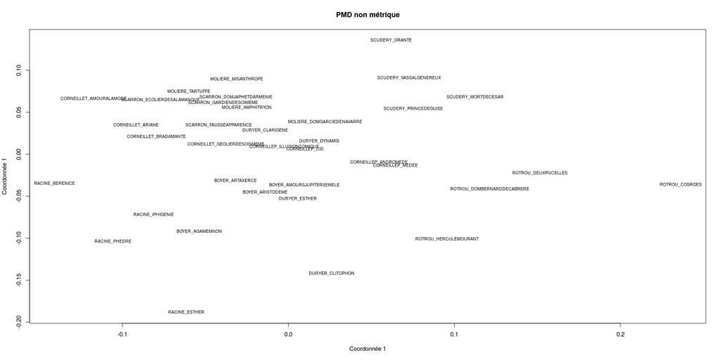

```r
x = fit$points[,1]
y = fit$points[,2]
plot(x, y, xlab="Coordonnée 1", ylab="Coordonnée 1",
  main="PMD non métrique", type="n")
text(x, y, labels = row.names(t(theatreTraite)), cex=.7)
```

# Annexes

## Installer ou mettre à jour des modules complémentaires pour R

Une des grandes forces de `R` vient de l’importante communauté qui l’entoure, et qui enrichit le langage par la création de modules complémentaires (*packages*) dédié à tel ou tel type d’analyse. Pour pouvoir les utiliser, il importe de les installer, et, quand on n’en a besoin, de les charger.

```r
#installation du module complémentaire stylo
#install.packages('stylo', dependencies=TRUE)
#install.packages('FactoMineR', dependencies=TRUE)
```

pour les charger, une fois installés (ex. `stylo`)

```r
#library(stylo)
```

et pour les mettre à jour

```r
#update.packages()
```